# Summer Lab 4

Dylan Francisco

July 21, 2023

# Lab 4a: Control Structures

## Introduction

The main purpose of this lab is to practice control structures in R:

- `if` and `else`: testing a condition and acting on it
- `for`: execute a loop a fixed number of times
- `while`: execute a loop while a condition is true
- `repeat`: execute an infinite loop (must break out of it to stop) • break: break the execution of a loop
- `next`: skip an iteration of a loop

You will need to modify the code chunks so that the code works within each of chunk (usually this means modifying anything in ALL CAPS). You will also need to modify the code outside the code chunk. When you get the desired result for each step, change `Eval=F` to `Eval=T` and knit the document to HTML to make sure it works. After you complete the lab, you should submit your HTML file of what you have completed to Canvas before the deadline.

## Part 1: Vector and Control Structures

### 1.1 (2 points)

Write code that creates a vector `x` that contains `100` random observations from the standard normal distribution (this is the normal distribution with the mean equal to `0` and the variance equal to `1`). Print out only the first five random observations in this vector.

```r
x <- rnorm(100, mean = 0, sd = 1)
print(x[1:5])
```

```
## [1]  0.40825977 -0.01882674 -1.03654267  0.50032139  0.54055477
```

### 1.2 (2 points)

Write code that replaces the observations in the vector `x` that are greater than or equal to `0` with a string of characters `"non-negative"` and the observations that are smaller than `0` with a string of characters `"negative"`. Hint: try `ifelse()` funtion. Print out the first five values in this new version of `x`.

```r
x <- ifelse(x >= 0, "non-negative", "negative")
print(x[1:5])
```

```
## [1] "non-negative" "negative"     "negative"     "non-negative" "non-negative"
```

### 1.3 (2 points)

Write `for`-Loop to count how many observations in the vector `x` are non-negative and how many observations are negative. (There are many easier ways to solve this problem. Use `for`-Loop or get 0 points. Use the `cat()` function to print out a sentence that states how many non-negative and negative obervations there are. For example, “The number of non-negative observations is 32”.

```r
nonNegativeCount = 0
negativeCount = 0

for (i in 1:length(x)) {
  if (x[i] == "non-negative") {
    nonNegativeCount = nonNegativeCount + 1
  } else {
    negativeCount = negativeCount +1
  }
}

cat("The number of non-negative observations is", nonNegativeCount, "\n")
```

```
## The number of non-negative observations is 46
```

```r
cat("The number of negative observations is", negativeCount)
```

```
## The number of negative observations is 54
```

## Part 2: Matrix and Control Structures

### 2.1 (4 points)

Create a $100000$ by $10$ matrix `A` with the numbers $1:1000000$. The first row of this matrix should be the numbers 1 to 10. The second row of this matrix should be the numbers 11 to 20. Create a `for`-loop that calculates the sum for each row of the matrix and save the results to a vector `sum_row` and print out the first five values of `sum_row`.

```r
A = matrix(1:1000000, nrow = 100000, ncol = 10, byrow = TRUE) # DO NOT CHANGE
sumRow = c()

for (i in 1:nrow(A)) {
  sumRow[i] = sum(A[i, ])
}
print(sumRow[1:5])
```

```
## [1]  55 155 255 355 455
```

Verify that your results are consistent with what you obtain with the built-in `rowSums` function.

```r
sum_row_rowSums = as.integer(rowSums(A))
sum_row_rowSums[1:5]
```

```
## [1]  55 155 255 355 455
```

### 2.2 (4 points)

Another common loop structure that is used is the `while` loop, which functions much like a `for` loop, but will only run as long as a test condition is `TRUE`. Modify your `for` loop from the previous exercise and make it into a `while` loop. Use the `identical()` function to check if the results from the `for` loop are the same as the results from `while` loop.

```r
sumRowWhile = c()
c = 0
while (c <= nrow(A)) {
  sumRowWhile[c] = sum(A[c, ])
  c = c + 1
}

identical(sumRow, sumRowWhile)
```

```
## [1] TRUE
```

## Part 3: Data Frame and Control Structures

### 3.1 (4 points)

Write a `for` loop to compute the mean of every column in `mtcars` and save the results to a vector `col_mean`. Ignore missing values when taking the mean.

```r
col_mean = c()
for (i in 1:ncol(mtcars)) {
  col_mean[i] = mean(mtcars[ ,i])
}
```

### 3.2 (2 points)

Compute the number of unique values in each column of `iris` and print the results during a loop. Use the `cat()` function to print out the values in a sentence with the corresponding name of the variable. For example, “The number of unique values for Sepal.Length is 35”.

```r
names(iris) #DO NOT CHANGE
```

```
## [1] "Sepal.Length" "Sepal.Width"  "Petal.Length" "Petal.Width"  "Species"
```

```r
columnNames = colnames(iris)

for (i in columnNames) {
  uniqueVals = unique(iris[[i]])
  numUnique = length(uniqueVals)
  cat("The number of unique values for", i, "is", numUnique, "\n")
}
```

```
## The number of unique values for Sepal.Length is 35
## The number of unique values for Sepal.Width is 23
## The number of unique values for Petal.Length is 43
## The number of unique values for Petal.Width is 22
## The number of unique values for Species is 3
```

# Lab 4b: Modeling Basics

## Introduction

In this lab, you will build predictive models for board game ratings. The dataset below was scraped from boardgamegeek.com and contains information on the top 4,999 board games. Below, you will see a preview of the data

```r
bgg<-read.csv("bgg.csv")
bgg2=bgg[,c(4:13,15:20)]
head(bgg2)
```

```
##                                           names min_players max_players
## 1                                    Gloomhaven           1           4
## 2                     Pandemic Legacy: Season 1           2           4
## 3 Through the Ages: A New Story of Civilization           2           4
## 4                             Terraforming Mars           1           5
## 5                             Twilight Struggle           2           2
## 6                          Star Wars: Rebellion           2           4
##   avg_time min_time max_time year avg_rating geek_rating num_votes age
## 1      120       60      120 2017    8.98893     8.61858     15376  12
## 2       60       60       60 2015    8.66140     8.50163     26063  13
## 3      240      180      240 2015    8.60673     8.30183     12352  14
## 4      120      120      120 2016    8.38461     8.19914     26004  12
## 5      180      120      180 2005    8.33954     8.19787     31301  13
## 6      240      180      240 2016    8.47439     8.16545     13336  14
##                                                                                                                                                                             mechanic
```

[output cut: 27 more lines]

## Board Game Analysis

### Q1 (1.5 Points)

There are 16 variables and we want to create some more. Create a new dataframe called $bgg3$ where you use the mutate function to create the following variables:

- *duration=2018-year+1*
- *vote.per.year=num_votes/duration*
- *own.per.year=owned/duration*
- *player.range=max_players-min_players*
- *log_vote=log(num_votes+1)*
- *log_own=log(owned+1)*
- *diff_rating=avg_rating-geek_rating*

```r
bgg3 <- bgg2 %>%
  mutate(duration = 2018 - year + 1,
         vote.per.year = num_votes / duration,
         own.per.year = owned / duration,
         player.range = max_players - min_players,
         log_vote = log(num_votes + 1),
         log_own = log(owned + 1),
         diff_rating = avg_rating - geek_rating)

head(bgg3)
```

```
##                                           names min_players max_players
## 1                                    Gloomhaven           1           4
## 2                     Pandemic Legacy: Season 1           2           4
## 3 Through the Ages: A New Story of Civilization           2           4
## 4                             Terraforming Mars           1           5
## 5                             Twilight Struggle           2           2
## 6                          Star Wars: Rebellion           2           4
##   avg_time min_time max_time year avg_rating geek_rating num_votes age
## 1      120       60      120 2017    8.98893     8.61858     15376  12
## 2       60       60       60 2015    8.66140     8.50163     26063  13
## 3      240      180      240 2015    8.60673     8.30183     12352  14
## 4      120      120      120 2016    8.38461     8.19914     26004  12
## 5      180      120      180 2005    8.33954     8.19787     31301  13
## 6      240      180      240 2016    8.47439     8.16545     13336  14
##                                                                                                                                                                             mechanic
```

[output cut: 34 more lines]

**Question:** In complete sentences, what is the purpose of adding 1 for the log transformed variables?

We add 1 to the log transformed variables to catch the potential problem of a num_votes or owned variable being a 0. Since we can not take the log of 0, we add 1 to all of the variables to so the data is consistent.

**Question:** In complete sentences, what is the purpose of adding 1 in the creation of the year variable?

The reason we add 1 in the year variable is to account for the current year. For example, if we want the duration from 2018 to 2015, it is a total of 4 years since 2015 is included. If we did not add the 1, the duration woud incorrectly be 3 years.

### Q2 (2 Points)

We hypothesize the geek rating increases when the number of votes increases and/or the ownership increases. Create four scatter plots showing the association with geek_rating and the following variables:

- *num_votes*
- *owned*
- *log_vote*
- *log_own*

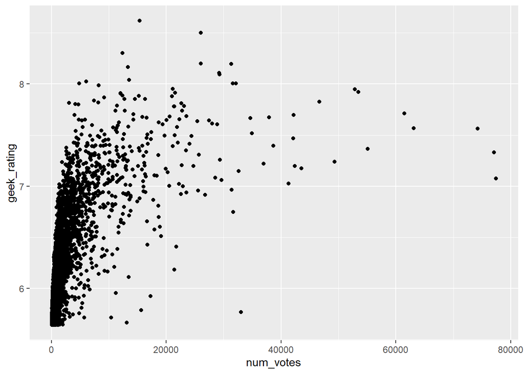

```r
ggplot(bgg3, aes(x = num_votes, y = geek_rating)) +
  geom_point()
```

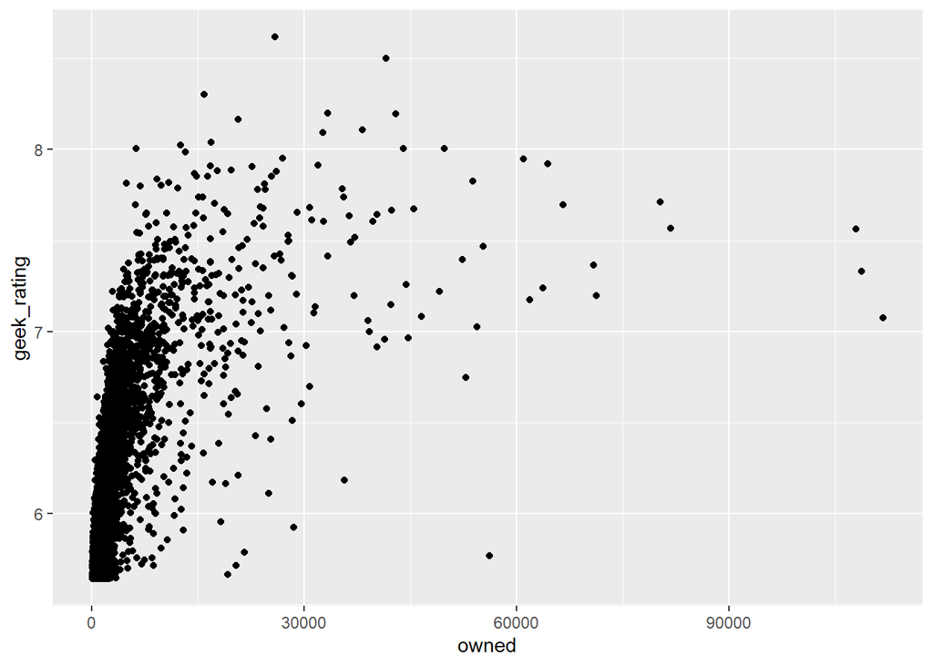

```r
ggplot(bgg3, aes(x = owned, y = geek_rating)) +
  geom_point()
```

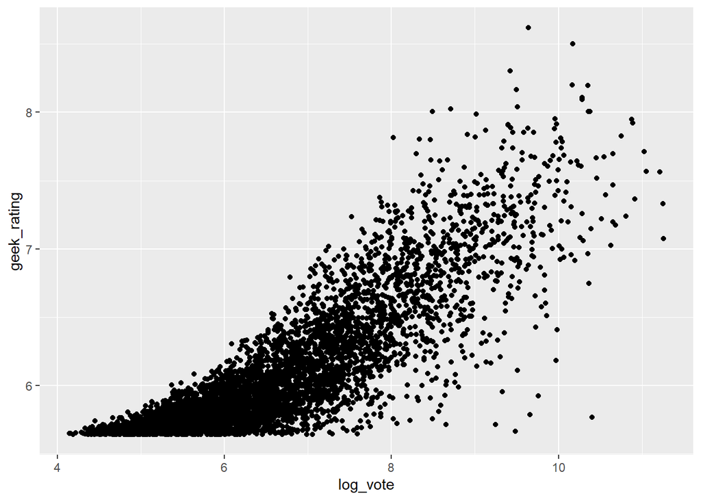

```r
ggplot(bgg3, aes(x = log_vote, y = geek_rating)) +
  geom_point()
```

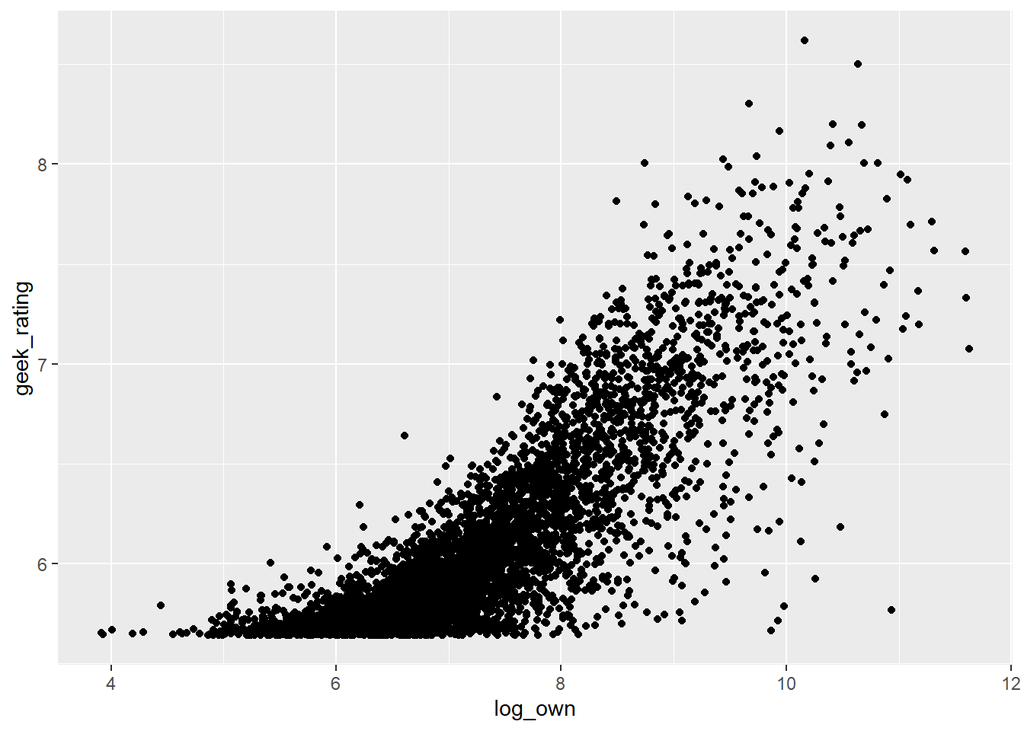

```r
ggplot(bgg3, aes(x = log_own, y = geek_rating)) +
  geom_point()
```

**Question:** In complete sentences, describe how the relationship changes when you take the log of the independent variable.

In this scenario when we take the log of the independent variable it changes the relationship between the variable and the geek rating. The original relationship appears to be a positive, concave down exponential relationship. When we take the log, it makes the data more of a linear model, which makes it easier to nderstand the relationship of the two variables much easier.

### Q3 (0.5 Points)

Randomly sample approximately 80% of the data in `bgg3` for a training dataset and the remaining will act as a test set. Call the training dataset `train.bgg` and the testing dataset `test.bgg`.

```r
set.seed(444)

bgg4= bgg3 %>%
        mutate(Set = sample(c("Train", "Test"), size = n(), prob = c(0.8, 0.2), replace = TRUE))

train.bgg<-filter(bgg4,Set=="Train")
test.bgg<-filter(bgg4,Set=="Test")
```

### Q4 (0.5 Points)

Now, we want to fit models to the training dataset. Use the `lm()` function to create 3 model objects in R called `lm1`, `lm2`, `lm3` based on the following linear models, respectively:

- $\textrm{geek_rating}=\beta_0+\beta_1 log(\textrm{num_votes})+\epsilon$
- $\textrm{geek_rating}=\beta_0+\beta_1 log(\textrm{owned})+\epsilon$
- $\textrm{geek_rating}=\beta_0+\beta_1 log(\textrm{owned})+ \beta_2 \textrm{vote.per.year}+ \beta_3 \textrm{weight} + \epsilon$

```r
lm1 = lm(geek_rating ~ log(num_votes),data=train.bgg)
lm2 = lm(geek_rating ~ log(owned),data=train.bgg)
lm3 = lm(geek_rating ~ log(owned) + vote.per.year + weight,data=train.bgg)
```

### Q5 (1 Point)

Add predictions and residuals for all 3 models to the test set. Create a new data frame called `test.bgg2` and give all your predictions and residuals different names. Use the `str()` function to show these variables were created

```r
test.bgg2 <- test.bgg %>%

  add_predictions(lm1, var = "LM1Pred") %>%
  add_predictions(lm2, var = "LM2Pred") %>%
  add_predictions(lm3, var = "LM3Pred") %>%
  add_residuals(lm1, var = "LM1Res") %>%
  add_residuals(lm2, var = "LM2Res") %>%
  add_residuals(lm3, var = "LM3Res")


str(test.bgg2)
```

```
## 'data.frame':    986 obs. of  30 variables:
##  $ names        : chr  "Great Western Trail" "Puerto Rico" "Agricola" "Mage Knight Board Game" ...
##  $ min_players  : int  2 2 1 1 2 1 2 2 1 2 ...
##  $ max_players  : int  4 5 5 4 4 4 2 5 8 6 ...
##  $ avg_time     : int  150 150 150 240 240 120 45 150 240 240 ...
##  $ min_time     : int  75 90 30 60 240 30 45 60 120 120 ...
##  $ max_time     : int  150 150 150 240 240 120 45 150 240 240 ...
##  $ year         : int  2016 2002 2007 2011 2006 2016 2012 2005 2013 2010 ...
##  $ avg_rating   : num  8.29 8.06 8.02 8.12 8.03 ...
##  $ geek_rating  : num  8.04 7.95 7.92 7.92 7.85 ...
##  $ num_votes    : int  13521 52849 53481 21524 16329 8145 22767 23494 20599 14262 ...
##  $ age          : int  12 12 12 14 12 12 14 12 14 14 ...
##  $ mechanic     : chr  "Deck / Pool Building, Hand Management, Point to Point Movement" "Variable Phase Order" "Area Enclosure, Card Drafting, Hand Management, Variable Player Powers, Worker Placement" "Card Drafting, Co-operative Play, Deck / Pool Building, Dice Rolling, Grid Movement, Hand Mana…
##  $ owned        : int  16869 61011 64468 31976 16397 10846 35645 23855 30839 14703 ...
##  $ category     : chr  "American West" "City Building, Economic, Farming" "Animals, Economic, Farming" "Adventure, Exploration, Fantasy, Fighting" ...
```

[output cut: 16 more lines]

### Q6 (0.5 Points)

Create a function called `MAE.func()` that returns the mean absolute error based on a vector of the residuals and test your function on the vector called `test`.

Solution 1:

```r
test=c(-5,-2,0,3,5)

MAE.func <- function(c) {
  mae <- mean(abs(c))
  return(mae)
}

MAE.func(test)
```

```
## [1] 3
```

### Q7 (1 Point)

Use your function on the `test.bgg2` to calculate the out-of-sample MAE of all three models based on the associated residuals. Make sure you display the mean absolute error from these different models in your output.

```r
bgg2MAE = test.bgg2 %>%
  select(LM1Res, LM2Res, LM3Res)
apply(bgg2MAE, 2, MAE.func)
```

```
##    LM1Res    LM2Res    LM3Res
## 0.1899382 0.2009498 0.1745277
```

**Question:** Which model does the best job at predicting the geek rating of these board games?

The model that best predicts the geek rating of these board games is Linear Model 3.

### Q8 (3 Points)

For the third model only, use 10-fold cross-validation and measure the out-of-sample mean absolute error. Print out the final cross-validated mean absolute error.

```r
data1=na.omit(test.bgg2) %>%
  crossv_kfold(10)
train.model.func = function(data, i, j){
  mod=lm(geek_rating ~ log(owned) + vote.per.year + weight, data = data)
  return(mod)
}


data2=data1 %>%
  mutate(tr.model=map(train,train.model.func, i=i, j=j))
data2predict = data2 %>%
    mutate(predict=map2(test,tr.model,~augment(.y,newdata=.x))) %>%
  select(predict) %>%
  unnest(cols = c(predict))


rmse.func= function(actual,predict){
  mse= mean((actual-predict)^2, na.rm = T)
  rmse = sqrt(mse)
  return(rmse)
}

rmse.func(actual = data2predict$geek_rating, predict = data2predict$.fitted)
```

```
## [1] 0.2274096
```

**Question:** What is the absolute difference between the out-of-sample mean absolute error measured using a test set and the mean absolute error measured using cross validation? When you type your answer in complete sentences use inline R code to calculate the absolute difference and input it directly into your sentence.